# R Notebook - Bryan Honeck

The Iris data set is known by just about anybody who has experimented with R or Python. It is a very popular data set because it can be used to demonstrate how the k-means clustering algorithm works. In this project, I implemented both the k-means and the k-nearest neighbors algorithms.

```r
head(iris)
```

|  | Sepal.Length | Sepal.Width | Petal.Length | Petal.Width | Species |
| --- | --- | --- | --- | --- | --- |
| 1 | 5.1 | 3.5 | 1.4 | 0.2 | setosa |
| 2 | 4.9 | 3.0 | 1.4 | 0.2 | setosa |
| 3 | 4.7 | 3.2 | 1.3 | 0.2 | setosa |
| 4 | 4.6 | 3.1 | 1.5 | 0.2 | setosa |
| 5 | 5.0 | 3.6 | 1.4 | 0.2 | setosa |
| 6 | 5.4 | 3.9 | 1.7 | 0.4 | setosa |

Check to see if there are any null values in the set. If null values are present, we can write a function to impute values based on species if possible. If there are no null values, we are good to move on to the next step.

```r
any(is.na(iris))
```

```
[1] FALSE
```

Now we need to check the variance of a couple variables to see if they are scaled. They are almost always never standardized. We need to save the species column to its own variable. Once that is done, we have to scale the data in order to avoid a faulty model.

```r
species <- iris[, 5]

var(iris[, 1])
```

```
[1] 0.6856935
```

```r
var(iris[, 2])
```

```
[1] 0.1899794
```

```r
standardized.iris <- scale(iris[, 1:4])

var(standardized.iris[, 1])
```

```
[1] 1
```

```r
var(standardized.iris[, 2])
```

```
[1] 1
```

Importing caTools allows us to split the data with the sample.split() function. We are basically assigning another variable here that will give a particular point in the data a boolean value.

```r
library(caTools)

final.standardized.iris <- cbind(standardized.iris, species)

sample <- sample.split(final.standardized.iris[, 5], SplitRatio = 0.7)

train <- subset(final.standardized.iris, sample == TRUE)
test <- subset(final.standardized.iris, sample == FALSE)
```

Call in the class package to use the knn() function. After running the model, we can check the error rate for k.

```r
library(class)

predictions.species <- knn(train[, 1:4], test[, 1:4], train[, 5], k =1)

#predictions.species

mean(test[, 5] != predictions.species)
```

```
[1] 0.06666667
```

Now, we run the model with multiple values for k.

```r
predictions.species <- NULL
error.rate <- NULL


for (i in 1:10) {
  predictions.species <- knn(train[, 1:4], test[, 1:4], train[, 5], k =i)
  error.rate[i] <- mean(test[, 5] != predictions.species)
}
```

Plot the error rates.

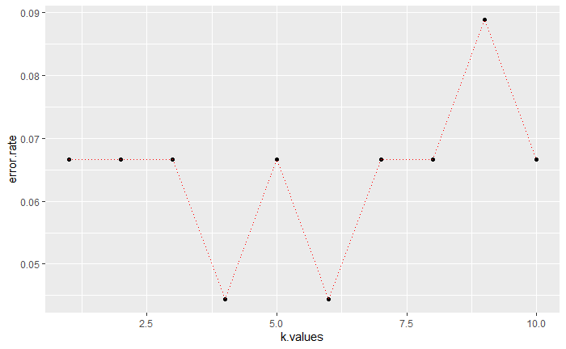

```r
library(ggplot2)
k.values <- 1:10

error.df <- data.frame(error.rate, k.values)

pl <- ggplot(error.df, aes(k.values, error.rate)) + geom_point() + geom_line(lty="dotted", color = "red")
pl
```

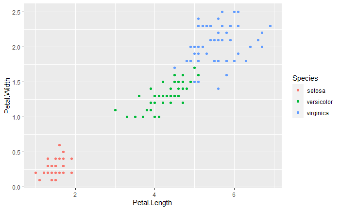

```r
pl2 <- ggplot(iris, aes(Petal.Length, Petal.Width)) + geom_point(aes(color = Species))
pl2
```

Simple to use the kmeans() functions to create the model.

```r
cluster.iris <- kmeans(iris[, 1:4], 3, nstart = 20)
cluster.iris
```

```
K-means clustering with 3 clusters of sizes 62, 50, 38

Cluster means:
  Sepal.Length Sepal.Width Petal.Length Petal.Width
1     5.901613    2.748387     4.393548    1.433871
2     5.006000    3.428000     1.462000    0.246000
3     6.850000    3.073684     5.742105    2.071053

Clustering vector:
  [1] 2 2 2 2 2 2 2 2 2 2 2 2 2 2 2 2 2 2 2 2 2 2 2 2 2 2 2 2 2 2 2 2 2 2 2 2 2 2 2 2 2 2 2 2 2 2 2 2 2 2 1 1 3 1
 [55] 1 1 1 1 1 1 1 1 1 1 1 1 1 1 1 1 1 1 1 1 1 1 1 3 1 1 1 1 1 1 1 1 1 1 1 1 1 1 1 1 1 1 1 1 1 1 3 1 3 3 3 3 1 3
[109] 3 3 3 3 3 1 1 3 3 3 3 1 3 1 3 1 3 3 1 1 3 3 3 3 3 1 3 3 3 3 1 3 3 3 1 3 3 3 1 3 3 1

Within cluster sum of squares by cluster:
[1] 39.82097 15.15100 23.87947
 (between_SS / total_SS =  88.4 %)

Available components:

[1] "cluster"      "centers"      "totss"        "withinss"     "tot.withinss" "betweenss"    "size"
[8] "iter"         "ifault"
```

Plot out the clusters.

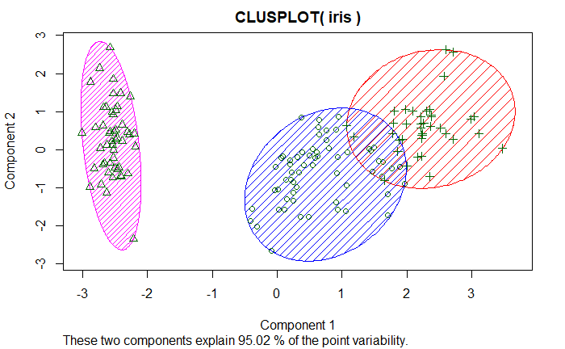

```r
library(cluster)

clusplot(iris, cluster.iris$cluster, color = TRUE, shade = TRUE, labels = 0, lines = 0)
```

```r
#install.packages("factoextra")
library(factoextra)

sil <- silhouette(cluster.iris$cluster, dist(iris))
```

```
NAs introduced by coercion
```

[output not shown]

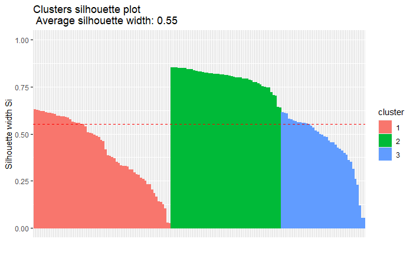

```r
fviz_silhouette(sil)
```